# Análisis y modelado del riesgo de impago en tarjetas de crédito

Gabriel Costa Riesco

13/06/2026

## Proyecto de minería de datos

Segmentación de clientes y predicción del riesgo de impago

**Gabriel Costa Riesco**

# 1 Resumen ejecutivo

El objetivo de este proyecto es estudiar el riesgo de impago de clientes con tarjeta de crédito. El análisis combina dos líneas de trabajo:

1. **Segmentación no supervisada**, para identificar perfiles de clientes a partir de su deuda mensual y de los pagos realizados.
2. **Clasificación supervisada**, para estimar si un cliente incurrirá en impago durante el siguiente periodo.

El proyecto cubre el proceso completo: comprensión del problema, preparación del dataset, análisis exploratorio, reducción de dimensionalidad, clustering, entrenamiento de modelos predictivos y evaluación de resultados.

# 2 Contexto y objetivos

El impago de una tarjeta de crédito genera pérdidas directas, aumenta los costes de recobro y complica la asignación de nuevos límites de crédito. La finalidad del análisis es aportar una base cuantitativa para:

- detectar grupos de clientes con comportamientos financieros similares;
- estudiar la relación entre deuda, pagos, retrasos y características demográficas;
- construir un modelo que ayude a identificar clientes con mayor riesgo;
- explicar las limitaciones que deben tenerse en cuenta antes de utilizar el modelo en un entorno real.

La variable objetivo es `Pago`. En la fuente original toma el valor `1` cuando se produce un impago en el mes siguiente y `0` cuando no se produce.

# 3 Metodología

La estructura del proyecto sigue **CRISP-DM**:

1. **Comprensión del negocio**: reducir la incertidumbre asociada a la concesión y gestión del crédito.
2. **Comprensión de los datos**: revisar variables, distribuciones, valores ausentes y categorías no documentadas.
3. **Preparación**: limpiar categorías, transformar tipos y renombrar variables para facilitar su interpretación.
4. **Modelado**: aplicar PCA, k-means, k-medians, PAM, una variante con distancia Manhattan, DBSCAN, OPTICS, árboles de decisión y Random Forest.
5. **Evaluación**: comparar cohesión de clústeres y métricas de clasificación.
6. **Aplicación**: traducir los resultados a perfiles de riesgo, manteniendo siempre supervisión humana.

# 4 Fuente de datos

Se utiliza el dataset [Default of Credit Card Clients](https://archive.ics.uci.edu/dataset/350/default+of+credit+card+clients), publicado en el UCI Machine Learning Repository.

El conjunto contiene 30.000 clientes de una entidad financiera de Taiwán y 25 variables relacionadas con:

- límite de crédito;
- sexo, educación, estado civil y edad;
- retrasos mensuales;
- deuda facturada durante seis meses;
- pagos realizados durante seis meses;
- impago en el siguiente periodo.

El dataset permite aplicar técnicas supervisadas y no supervisadas. Su tamaño es suficiente para separar entrenamiento y test, aunque su antigüedad y su contexto geográfico limitan la generalización de las conclusiones.

# 5 Carga y preparación

## 5.1 Lectura de los datos

```r
data_path <- file.path("data", "creditcard.xls")

if (!file.exists(data_path)) {
  stop("No se encuentra el archivo data/creditcard.xls")
}

clientes_raw <- readxl::read_excel(
  data_path,
  skip = 1,
  col_names = TRUE
)

dim(clientes_raw)
```

```
## [1] 30000    25
```

```r
head(clientes_raw)
```

```
## # A tibble: 6 × 25
##      ID LIMIT_BAL   SEX EDUCATION MARRIAGE   AGE PAY_0 PAY_2 PAY_3 PAY_4 PAY_5
##   <dbl>     <dbl> <dbl>     <dbl>    <dbl> <dbl> <dbl> <dbl> <dbl> <dbl> <dbl>
## 1     1     20000     2         2        1    24     2     2    -1    -1    -2
## 2     2    120000     2         2        2    26    -1     2     0     0     0
## 3     3     90000     2         2        2    34     0     0     0     0     0
## 4     4     50000     2         2        1    37     0     0     0     0     0
## 5     5     50000     1         2        1    57    -1     0    -1     0     0
## 6     6     50000     1         1        2    37     0     0     0     0     0
## # ℹ 14 more variables: PAY_6 <dbl>, BILL_AMT1 <dbl>, BILL_AMT2 <dbl>,
## #   BILL_AMT3 <dbl>, BILL_AMT4 <dbl>, BILL_AMT5 <dbl>, BILL_AMT6 <dbl>,
## #   PAY_AMT1 <dbl>, PAY_AMT2 <dbl>, PAY_AMT3 <dbl>, PAY_AMT4 <dbl>,
## #   PAY_AMT5 <dbl>, PAY_AMT6 <dbl>, `default payment next month` <dbl>
```

El archivo original contiene 30.000 observaciones y 25 columnas. La primera revisión permite comprobar los nombres, tipos y rangos disponibles.

```r
str(clientes_raw)
```

```
## tibble [30,000 × 25] (S3: tbl_df/tbl/data.frame)
##  $ ID                        : num [1:30000] 1 2 3 4 5 6 7 8 9 10 ...
##  $ LIMIT_BAL                 : num [1:30000] 20000 120000 90000 50000 50000 50000 500000 100000 140000 20000 ...
##  $ SEX                       : num [1:30000] 2 2 2 2 1 1 1 2 2 1 ...
##  $ EDUCATION                 : num [1:30000] 2 2 2 2 2 1 1 2 3 3 ...
##  $ MARRIAGE                  : num [1:30000] 1 2 2 1 1 2 2 2 1 2 ...
##  $ AGE                       : num [1:30000] 24 26 34 37 57 37 29 23 28 35 ...
##  $ PAY_0                     : num [1:30000] 2 -1 0 0 -1 0 0 0 0 -2 ...
##  $ PAY_2                     : num [1:30000] 2 2 0 0 0 0 0 -1 0 -2 ...
##  $ PAY_3                     : num [1:30000] -1 0 0 0 -1 0 0 -1 2 -2 ...
##  $ PAY_4                     : num [1:30000] -1 0 0 0 0 0 0 0 0 -2 ...
##  $ PAY_5                     : num [1:30000] -2 0 0 0 0 0 0 0 0 -1 ...
##  $ PAY_6                     : num [1:30000] -2 2 0 0 0 0 0 -1 0 -1 ...
##  $ BILL_AMT1                 : num [1:30000] 3913 2682 29239 46990 8617 ...
##  $ BILL_AMT2                 : num [1:30000] 3102 1725 14027 48233 5670 ...
##  $ BILL_AMT3                 : num [1:30000] 689 2682 13559 49291 35835 ...
##  $ BILL_AMT4                 : num [1:30000] 0 3272 14331 28314 20940 ...
##  $ BILL_AMT5                 : num [1:30000] 0 3455 14948 28959 19146 ...
##  $ BILL_AMT6                 : num [1:30000] 0 3261 15549 29547 19131 ...
##  $ PAY_AMT1                  : num [1:30000] 0 0 1518 2000 2000 ...
##  $ PAY_AMT2                  : num [1:30000] 689 1000 1500 2019 36681 ...
##  $ PAY_AMT3                  : num [1:30000] 0 1000 1000 1200 10000 657 38000 0 432 0 ...
##  $ PAY_AMT4                  : num [1:30000] 0 1000 1000 1100 9000 ...
##  $ PAY_AMT5                  : num [1:30000] 0 0 1000 1069 689 ...
##  $ PAY_AMT6                  : num [1:30000] 0 2000 5000 1000 679 ...
##  $ default payment next month: num [1:30000] 1 1 0 0 0 0 0 0 0 0 ...
```

```r
summary(clientes_raw)
```

```
##        ID          LIMIT_BAL            SEX          EDUCATION
##  Min.   :    1   Min.   :  10000   Min.   :1.000   Min.   :0.000
##  1st Qu.: 7501   1st Qu.:  50000   1st Qu.:1.000   1st Qu.:1.000
##  Median :15000   Median : 140000   Median :2.000   Median :2.000
##  Mean   :15000   Mean   : 167484   Mean   :1.604   Mean   :1.853
##  3rd Qu.:22500   3rd Qu.: 240000   3rd Qu.:2.000   3rd Qu.:2.000
##  Max.   :30000   Max.   :1000000   Max.   :2.000   Max.   :6.000
##     MARRIAGE          AGE            PAY_0             PAY_2
##  Min.   :0.000   Min.   :21.00   Min.   :-2.0000   Min.   :-2.0000
##  1st Qu.:1.000   1st Qu.:28.00   1st Qu.:-1.0000   1st Qu.:-1.0000
##  Median :2.000   Median :34.00   Median : 0.0000   Median : 0.0000
##  Mean   :1.552   Mean   :35.49   Mean   :-0.0167   Mean   :-0.1338
##  3rd Qu.:2.000   3rd Qu.:41.00   3rd Qu.: 0.0000   3rd Qu.: 0.0000
##  Max.   :3.000   Max.   :79.00   Max.   : 8.0000   Max.   : 8.0000
##      PAY_3             PAY_4             PAY_5             PAY_6
##  Min.   :-2.0000   Min.   :-2.0000   Min.   :-2.0000   Min.   :-2.0000
##  1st Qu.:-1.0000   1st Qu.:-1.0000   1st Qu.:-1.0000   1st Qu.:-1.0000
##  Median : 0.0000   Median : 0.0000   Median : 0.0000   Median : 0.0000
##  Mean   :-0.1662   Mean   :-0.2207   Mean   :-0.2662   Mean   :-0.2911
##  3rd Qu.: 0.0000   3rd Qu.: 0.0000   3rd Qu.: 0.0000   3rd Qu.: 0.0000
##  Max.   : 8.0000   Max.   : 8.0000   Max.   : 8.0000   Max.   : 8.0000
##    BILL_AMT1         BILL_AMT2        BILL_AMT3         BILL_AMT4
##  Min.   :-165580   Min.   :-69777   Min.   :-157264   Min.   :-170000
##  1st Qu.:   3559   1st Qu.:  2985   1st Qu.:   2666   1st Qu.:   2327
##  Median :  22382   Median : 21200   Median :  20089   Median :  19052
##  Mean   :  51223   Mean   : 49179   Mean   :  47013   Mean   :  43263
##  3rd Qu.:  67091   3rd Qu.: 64006   3rd Qu.:  60165   3rd Qu.:  54506
##  Max.   : 964511   Max.   :983931   Max.   :1664089   Max.   : 891586
##    BILL_AMT5        BILL_AMT6          PAY_AMT1         PAY_AMT2
##  Min.   :-81334   Min.   :-339603   Min.   :     0   Min.   :      0
##  1st Qu.:  1763   1st Qu.:   1256   1st Qu.:  1000   1st Qu.:    833
##  Median : 18105   Median :  17071   Median :  2100   Median :   2009
##  Mean   : 40311   Mean   :  38872   Mean   :  5664   Mean   :   5921
##  3rd Qu.: 50191   3rd Qu.:  49198   3rd Qu.:  5006   3rd Qu.:   5000
##  Max.   :927171   Max.   : 961664   Max.   :873552   Max.   :1684259
##     PAY_AMT3         PAY_AMT4         PAY_AMT5           PAY_AMT6
##  Min.   :     0   Min.   :     0   Min.   :     0.0   Min.   :     0.0
##  1st Qu.:   390   1st Qu.:   296   1st Qu.:   252.5   1st Qu.:   117.8
##  Median :  1800   Median :  1500   Median :  1500.0   Median :  1500.0
##  Mean   :  5226   Mean   :  4826   Mean   :  4799.4   Mean   :  5215.5
##  3rd Qu.:  4505   3rd Qu.:  4013   3rd Qu.:  4031.5   3rd Qu.:  4000.0
##  Max.   :896040   Max.   :621000   Max.   :426529.0   Max.   :528666.0
##  default payment next month
##  Min.   :0.0000
##  1st Qu.:0.0000
##  Median :0.0000
##  Mean   :0.2212
##  3rd Qu.:0.0000
##  Max.   :1.0000
```

```r
colSums(is.na(clientes_raw))
```

```
##                         ID                  LIMIT_BAL
##                          0                          0
##                        SEX                  EDUCATION
##                          0                          0
##                   MARRIAGE                        AGE
##                          0                          0
##                      PAY_0                      PAY_2
##                          0                          0
##                      PAY_3                      PAY_4
##                          0                          0
##                      PAY_5                      PAY_6
##                          0                          0
##                  BILL_AMT1                  BILL_AMT2
##                          0                          0
##                  BILL_AMT3                  BILL_AMT4
##                          0                          0
##                  BILL_AMT5                  BILL_AMT6
##                          0                          0
##                   PAY_AMT1                   PAY_AMT2
##                          0                          0
##                   PAY_AMT3                   PAY_AMT4
##                          0                          0
##                   PAY_AMT5                   PAY_AMT6
##                          0                          0
## default payment next month
##                          0
```

## 5.2 Limpieza de categorías

La documentación define cuatro categorías de educación y tres de estado civil. Los códigos fuera de esos rangos no tienen una interpretación clara, por lo que se eliminan antes del modelado.

```r
clientes <- clientes_raw |>
  dplyr::filter(
    EDUCATION %in% c(1, 2, 3, 4),
    MARRIAGE %in% c(1, 2, 3)
  )

filas_eliminadas <- nrow(clientes_raw) - nrow(clientes)
porcentaje_eliminado <- 100 * filas_eliminadas / nrow(clientes_raw)

data.frame(
  filas_originales = nrow(clientes_raw),
  filas_finales = nrow(clientes),
  filas_eliminadas = filas_eliminadas,
  porcentaje_eliminado = round(porcentaje_eliminado, 3)
)
```

```
##   filas_originales filas_finales filas_eliminadas porcentaje_eliminado
## 1            30000         29601              399                 1.33
```

La pérdida de observaciones es muy reducida y mejora la interpretabilidad de las variables categóricas.

## 5.3 Transformación y nombres descriptivos

```r
rename_map <- c(
  "default payment next month" = "Pago",
  "PAY_0" = "RETRASOS_Septiembre",
  "PAY_2" = "RETRASOS_Agosto",
  "PAY_3" = "RETRASOS_Julio",
  "PAY_4" = "RETRASOS_Junio",
  "PAY_5" = "RETRASOS_Mayo",
  "PAY_6" = "RETRASOS_Abril",
  "BILL_AMT1" = "DEUDA_Septiembre",
  "BILL_AMT2" = "DEUDA_Agosto",
  "BILL_AMT3" = "DEUDA_Julio",
  "BILL_AMT4" = "DEUDA_Junio",
  "BILL_AMT5" = "DEUDA_Mayo",
  "BILL_AMT6" = "DEUDA_Abril",
  "PAY_AMT1" = "PAGADO_Septiembre",
  "PAY_AMT2" = "PAGADO_Agosto",
  "PAY_AMT3" = "PAGADO_Julio",
  "PAY_AMT4" = "PAGADO_Junio",
  "PAY_AMT5" = "PAGADO_Mayo",
  "PAY_AMT6" = "PAGADO_Abril"
)

for (old_name in names(rename_map)) {
  names(clientes)[names(clientes) == old_name] <- rename_map[[old_name]]
}

clientes <- clientes |>
  dplyr::mutate(
    SEX = factor(SEX, levels = c(1, 2), labels = c("Hombre", "Mujer")),
    EDUCATION = factor(
      EDUCATION,
      levels = c(1, 2, 3, 4),
      labels = c(
        "Posgrado", "Universidad",
        "Graduado escolar", "Otro"
      )
    ),
    MARRIAGE = factor(
      MARRIAGE,
      levels = c(1, 2, 3),
      labels = c("Casado", "Soltero", "Otro")
    ),
    Pago = factor(
      Pago,
      levels = c(0, 1),
      labels = c("No impago", "Impago")
    ),
    GEdad = cut(
      AGE,
      breaks = c(-Inf, 30, 45, 60, Inf),
      labels = c("Joven", "Adulto joven", "Adulto", "Mayor")
    )
  )

head(clientes)
```

```
## # A tibble: 6 × 26
##      ID LIMIT_BAL SEX    EDUCATION   MARRIAGE   AGE RETRASOS_Septiembre
##   <dbl>     <dbl> <fct>  <fct>       <fct>    <dbl>               <dbl>
## 1     1     20000 Mujer  Universidad Casado      24                   2
## 2     2    120000 Mujer  Universidad Soltero     26                  -1
## 3     3     90000 Mujer  Universidad Soltero     34                   0
## 4     4     50000 Mujer  Universidad Casado      37                   0
## 5     5     50000 Hombre Universidad Casado      57                  -1
## 6     6     50000 Hombre Posgrado    Soltero     37                   0
## # ℹ 19 more variables: RETRASOS_Agosto <dbl>, RETRASOS_Julio <dbl>,
## #   RETRASOS_Junio <dbl>, RETRASOS_Mayo <dbl>, RETRASOS_Abril <dbl>,
## #   DEUDA_Septiembre <dbl>, DEUDA_Agosto <dbl>, DEUDA_Julio <dbl>,
## #   DEUDA_Junio <dbl>, DEUDA_Mayo <dbl>, DEUDA_Abril <dbl>,
## #   PAGADO_Septiembre <dbl>, PAGADO_Agosto <dbl>, PAGADO_Julio <dbl>,
## #   PAGADO_Junio <dbl>, PAGADO_Mayo <dbl>, PAGADO_Abril <dbl>, Pago <fct>,
## #   GEdad <fct>
```

## 5.4 Diccionario resumido

| Grupo | Variables | Interpretación |
| --- | --- | --- |
| Identificación | `ID` | Identificador único del cliente |
| Crédito | `LIMIT_BAL` | Límite concedido en dólares taiwaneses |
| Perfil | `SEX`, `EDUCATION`, `MARRIAGE`, `AGE`, `GEdad` | Características demográficas |
| Retrasos | `RETRASOS_*` | Estado de pago durante seis meses |
| Deuda | `DEUDA_*` | Importe facturado durante seis meses |
| Pagos | `PAGADO_*` | Importe pagado durante seis meses |
| Objetivo | `Pago` | Impago o no impago en el periodo siguiente |

```r
data.frame(
  variable = names(clientes),
  tipo = vapply(clientes, function(x) class(x)[1], character(1)),
  ausentes = vapply(clientes, function(x) sum(is.na(x)), numeric(1))
)
```

```
##                                variable    tipo ausentes
## ID                                   ID numeric        0
## LIMIT_BAL                     LIMIT_BAL numeric        0
## SEX                                 SEX  factor        0
## EDUCATION                     EDUCATION  factor        0
## MARRIAGE                       MARRIAGE  factor        0
## AGE                                 AGE numeric        0
## RETRASOS_Septiembre RETRASOS_Septiembre numeric        0
## RETRASOS_Agosto         RETRASOS_Agosto numeric        0
## RETRASOS_Julio           RETRASOS_Julio numeric        0
## RETRASOS_Junio           RETRASOS_Junio numeric        0
## RETRASOS_Mayo             RETRASOS_Mayo numeric        0
## RETRASOS_Abril           RETRASOS_Abril numeric        0
## DEUDA_Septiembre       DEUDA_Septiembre numeric        0
## DEUDA_Agosto               DEUDA_Agosto numeric        0
## DEUDA_Julio                 DEUDA_Julio numeric        0
## DEUDA_Junio                 DEUDA_Junio numeric        0
## DEUDA_Mayo                   DEUDA_Mayo numeric        0
## DEUDA_Abril                 DEUDA_Abril numeric        0
## PAGADO_Septiembre     PAGADO_Septiembre numeric        0
## PAGADO_Agosto             PAGADO_Agosto numeric        0
## PAGADO_Julio               PAGADO_Julio numeric        0
## PAGADO_Junio               PAGADO_Junio numeric        0
## PAGADO_Mayo                 PAGADO_Mayo numeric        0
## PAGADO_Abril               PAGADO_Abril numeric        0
## Pago                               Pago  factor        0
## GEdad                             GEdad  factor        0
```

# 6 Análisis exploratorio

## 6.1 Distribución de la variable objetivo

```r
prop.table(table(clientes$Pago))
```

```
##
## No impago    Impago
## 0.7768656 0.2231344
```

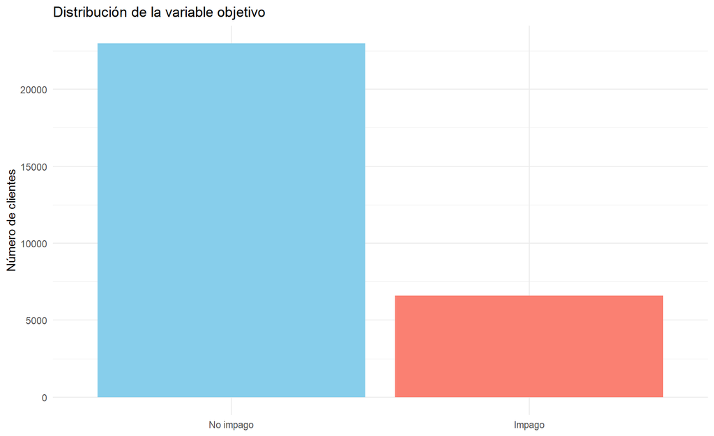

```r
ggplot(clientes, aes(x = Pago, fill = Pago)) +
  geom_bar() +
  scale_fill_manual(values = c("No impago" = "skyblue", "Impago" = "salmon")) +
  labs(
    title = "Distribución de la variable objetivo",
    x = NULL,
    y = "Número de clientes"
  ) +
  theme_minimal() +
  theme(legend.position = "none")
```

La clase `No impago` es mayoritaria. Este desequilibrio debe considerarse al interpretar la accuracy: un modelo que siempre predijera la clase mayoritaria podría obtener un porcentaje aparentemente alto sin detectar correctamente los impagos.

## 6.2 Perfil demográfico

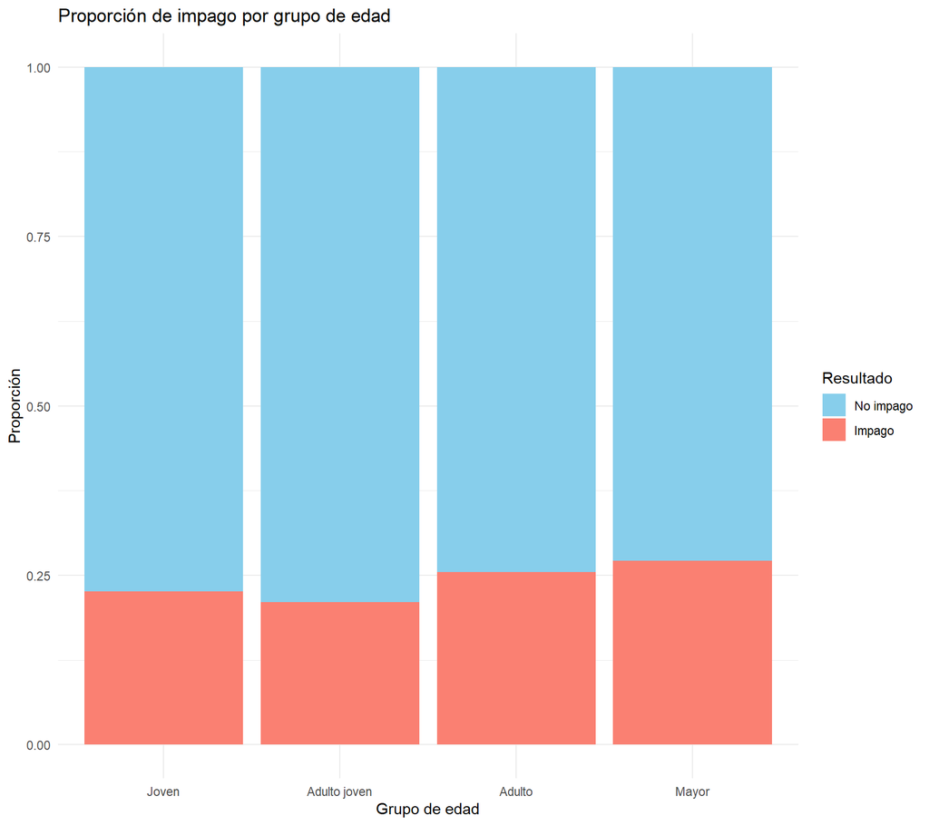

```r
p_edad <- ggplot(clientes, aes(x = GEdad, fill = Pago)) +
  geom_bar(position = "fill") +
  scale_fill_manual(values = c("No impago" = "skyblue", "Impago" = "salmon")) +
  labs(
    title = "Proporción de impago por grupo de edad",
    x = "Grupo de edad",
    y = "Proporción",
    fill = "Resultado"
  ) +
  theme_minimal()

p_educacion <- ggplot(clientes, aes(x = EDUCATION, fill = Pago)) +
  geom_bar(position = "fill") +
  scale_fill_manual(values = c("No impago" = "skyblue", "Impago" = "salmon")) +
  labs(
    title = "Proporción de impago por educación",
    x = "Educación",
    y = "Proporción",
    fill = "Resultado"
  ) +
  theme_minimal() +
  theme(axis.text.x = element_text(angle = 30, hjust = 1))

p_edad
```

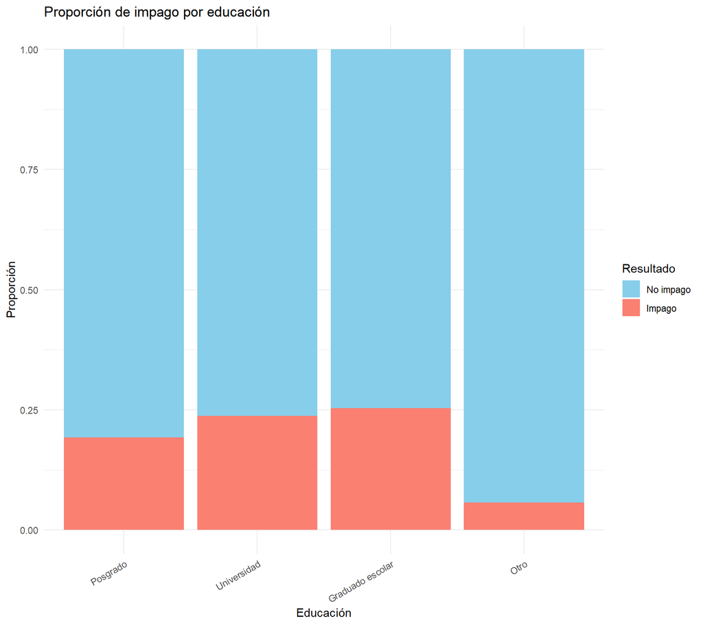

```r
p_educacion
```

Las variables demográficas muestran diferencias, pero no ofrecen por sí solas una separación fuerte entre clientes con y sin impago. Será necesario incorporar el historial financiero.

```r
prop.table(table(clientes$SEX, clientes$Pago), 1)
```

```
##
##          No impago    Impago
##   Hombre 0.7564277 0.2435723
##   Mujer  0.7903108 0.2096892
```

```r
prop.table(table(clientes$EDUCATION, clientes$Pago), 1)
```

```
##
##                     No impago     Impago
##   Posgrado         0.80757962 0.19242038
##   Universidad      0.76262122 0.23737878
##   Graduado escolar 0.74697312 0.25302688
##   Otro             0.94308943 0.05691057
```

```r
prop.table(table(clientes$MARRIAGE, clientes$Pago), 1)
```

```
##
##           No impago    Impago
##   Casado  0.7631520 0.2368480
##   Soltero 0.7893838 0.2106162
##   Otro    0.7358491 0.2641509
```

```r
prop.table(table(clientes$GEdad, clientes$Pago), 1)
```

```
##
##                No impago    Impago
##   Joven        0.7739242 0.2260758
##   Adulto joven 0.7897011 0.2102989
##   Adulto       0.7453071 0.2546929
##   Mayor        0.7286245 0.2713755
```

## 6.3 Crédito, deuda y pagos

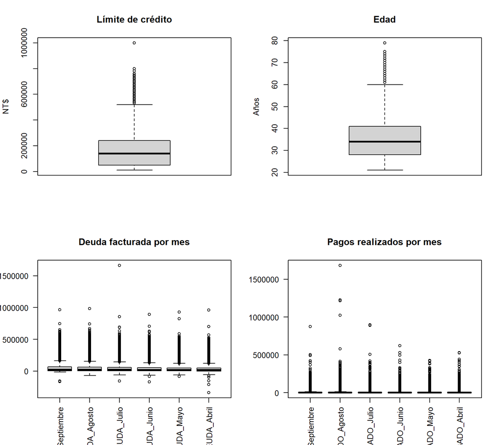

```r
par(mfrow = c(2, 2))
boxplot(clientes$LIMIT_BAL, main = "Límite de crédito", ylab = "NT$")
boxplot(clientes$AGE, main = "Edad", ylab = "Años")
boxplot(
  clientes[, grep("^DEUDA_", names(clientes))],
  main = "Deuda facturada por mes",
  las = 2
)
boxplot(
  clientes[, grep("^PAGADO_", names(clientes))],
  main = "Pagos realizados por mes",
  las = 2
)
```

```r
par(mfrow = c(1, 1))
```

Los importes presentan una dispersión elevada. En este contexto los valores extremos no son necesariamente errores: clientes con límites y deudas muy distintos forman parte de la naturaleza del problema. Para evitar que las variables con mayor escala dominen los algoritmos basados en distancia, se trabajará también con datos estandarizados.

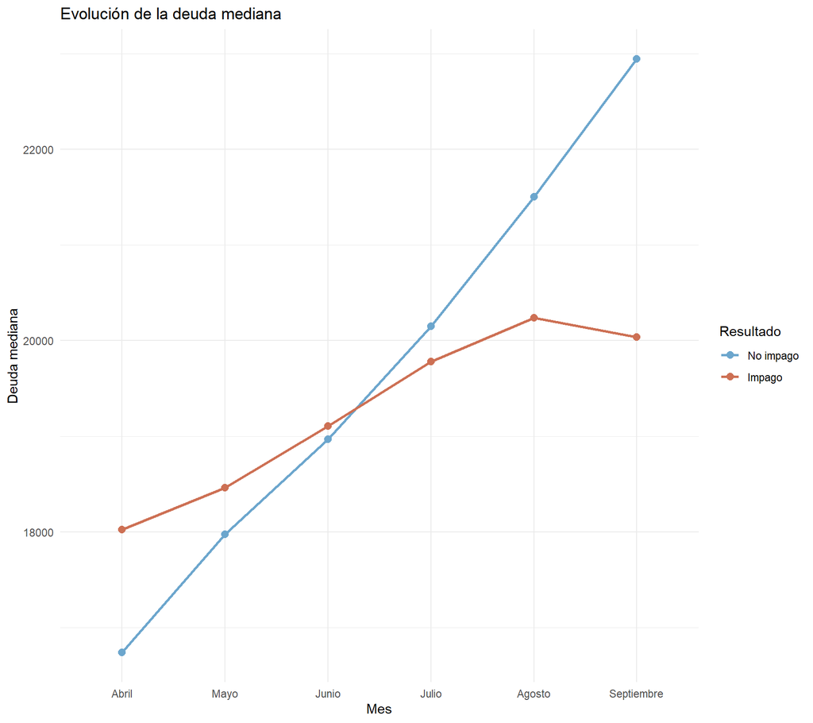

```r
orden_meses <- c("Abril", "Mayo", "Junio", "Julio", "Agosto", "Septiembre")

deuda_larga <- clientes |>
  dplyr::select(Pago, dplyr::starts_with("DEUDA_")) |>
  tidyr::pivot_longer(
    cols = -Pago,
    names_to = "Mes",
    values_to = "Importe"
  ) |>
  dplyr::mutate(
    Mes = factor(
      sub("DEUDA_", "", Mes),
      levels = orden_meses
    )
  )

pagos_largos <- clientes |>
  dplyr::select(Pago, dplyr::starts_with("PAGADO_")) |>
  tidyr::pivot_longer(
    cols = -Pago,
    names_to = "Mes",
    values_to = "Importe"
  ) |>
  dplyr::mutate(
    Mes = factor(
      sub("PAGADO_", "", Mes),
      levels = orden_meses
    )
  )

ggplot(deuda_larga, aes(x = Mes, y = Importe, color = Pago, group = Pago)) +
  stat_summary(fun = median, geom = "line", linewidth = 1) +
  stat_summary(fun = median, geom = "point", size = 2.5) +
  scale_color_manual(values = c("No impago" = "skyblue3", "Impago" = "salmon3")) +
  labs(
    title = "Evolución de la deuda mediana",
    x = "Mes",
    y = "Deuda mediana",
    color = "Resultado"
  ) +
  theme_minimal()
```

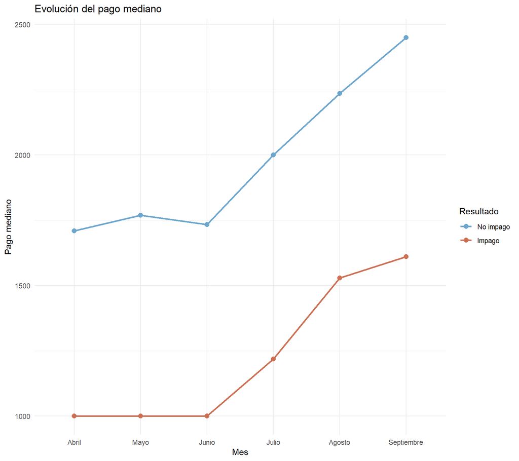

```r
ggplot(pagos_largos, aes(x = Mes, y = Importe, color = Pago, group = Pago)) +
  stat_summary(fun = median, geom = "line", linewidth = 1) +
  stat_summary(fun = median, geom = "point", size = 2.5) +
  scale_color_manual(values = c("No impago" = "skyblue3", "Impago" = "salmon3")) +
  labs(
    title = "Evolución del pago mediano",
    x = "Mes",
    y = "Pago mediano",
    color = "Resultado"
  ) +
  theme_minimal()
```

## 6.4 Correlaciones

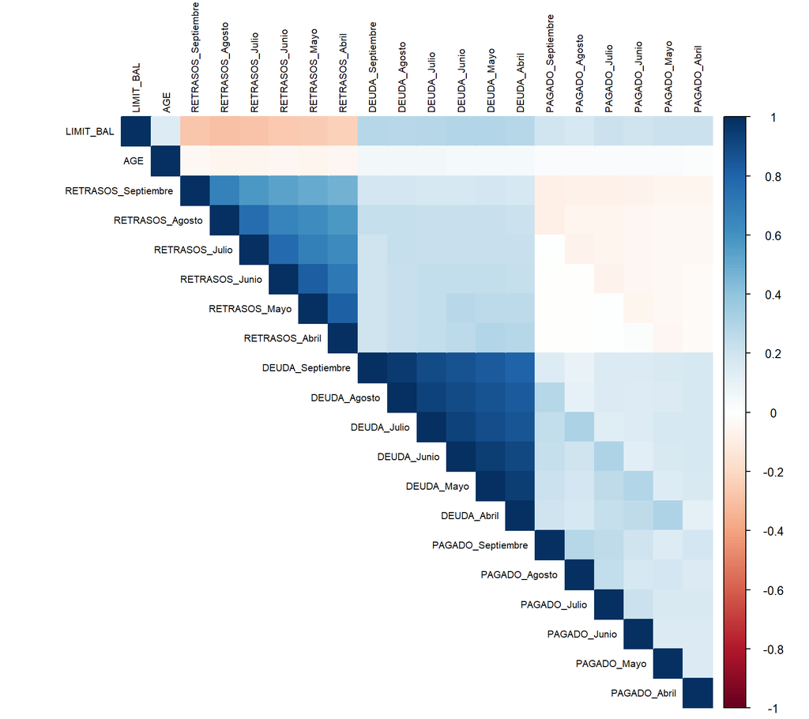

```r
variables_numericas <- clientes |>
  dplyr::select(
    LIMIT_BAL, AGE,
    dplyr::starts_with("RETRASOS_"),
    dplyr::starts_with("DEUDA_"),
    dplyr::starts_with("PAGADO_")
  )

matriz_cor <- cor(variables_numericas)

corrplot::corrplot(
  matriz_cor,
  method = "color",
  type = "upper",
  tl.cex = 0.65,
  tl.col = "black"
)
```

Los importes de deuda de meses consecutivos están muy correlacionados. También existe relación entre los estados de retraso. Esta redundancia justifica aplicar PCA como herramienta de síntesis.

# 7 Reducción de dimensionalidad con PCA

El PCA se aplica a las doce variables continuas de deuda y pagos. Se estandarizan previamente para que todas contribuyan en una escala comparable.

```r
variables_cluster <- clientes |>
  dplyr::select(
    dplyr::starts_with("DEUDA_"),
    dplyr::starts_with("PAGADO_")
  )

variables_cluster_scaled <- scale(variables_cluster)

pca_result <- prcomp(
  variables_cluster_scaled,
  center = FALSE,
  scale. = FALSE
)

varianza <- pca_result$sdev^2 / sum(pca_result$sdev^2)
resumen_pca <- data.frame(
  componente = paste0("PC", seq_along(varianza)),
  varianza = round(100 * varianza, 2),
  varianza_acumulada = round(100 * cumsum(varianza), 2)
)

knitr::kable(resumen_pca)
```

| componente | varianza | varianza_acumulada |
| --- | --- | --- |
| PC1 | 48.18 | 48.18 |
| PC2 | 13.61 | 61.79 |
| PC3 | 7.57 | 69.36 |
| PC4 | 7.36 | 76.72 |
| PC5 | 7.25 | 83.97 |
| PC6 | 6.48 | 90.45 |
| PC7 | 6.05 | 96.49 |
| PC8 | 2.18 | 98.67 |
| PC9 | 0.59 | 99.26 |
| PC10 | 0.34 | 99.60 |
| PC11 | 0.21 | 99.81 |
| PC12 | 0.19 | 100.00 |

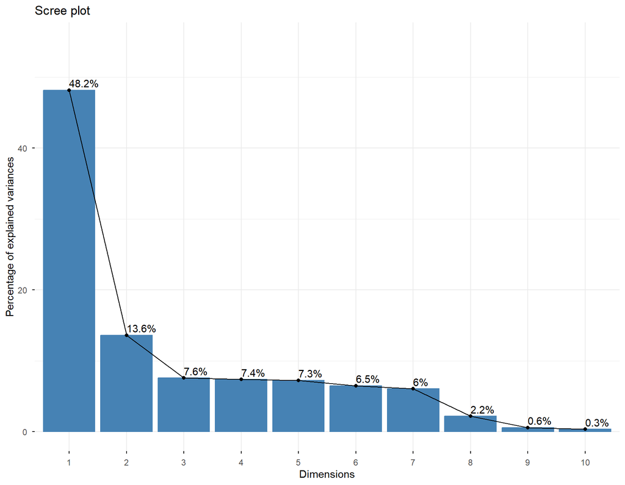

```r
factoextra::fviz_eig(
  pca_result,
  addlabels = TRUE,
  ylim = c(0, 55)
)
```

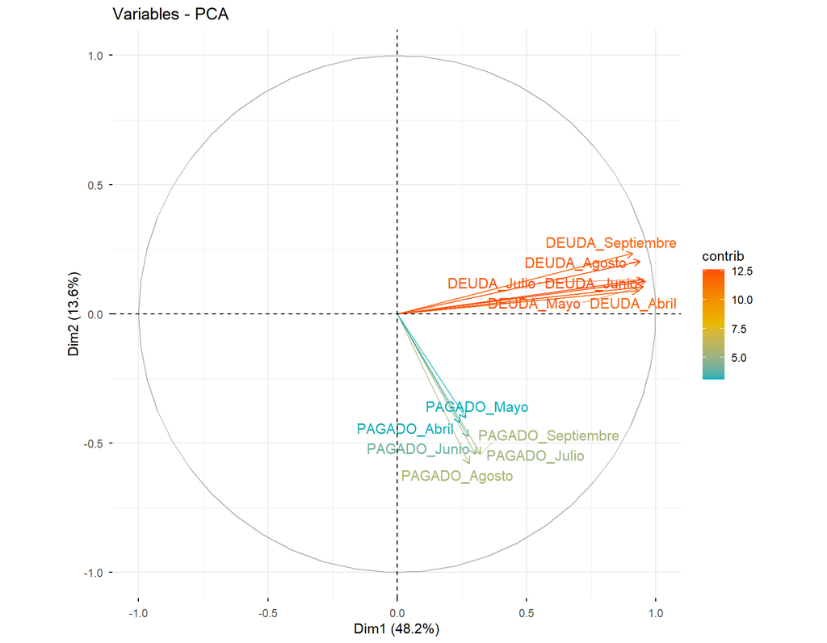

```r
factoextra::fviz_pca_var(
  pca_result,
  col.var = "contrib",
  gradient.cols = c("#00AFBB", "#E7B800", "#FC4E07"),
  repel = TRUE
)
```

```r
n_componentes_90 <- which(cumsum(varianza) >= 0.90)[1]
n_componentes_90
```

```
## [1] 6
```

```r
componentes_financieros <- as.data.frame(
  pca_result$x[, seq_len(n_componentes_90), drop = FALSE]
)

names(componentes_financieros) <- paste0(
  "PCA_FINANCIERO_",
  seq_len(n_componentes_90)
)

clientes_pca <- dplyr::bind_cols(clientes, componentes_financieros)
head(componentes_financieros)
```

```
##   PCA_FINANCIERO_1 PCA_FINANCIERO_2 PCA_FINANCIERO_3 PCA_FINANCIERO_4
## 1       -1.7499268        0.2242172       0.08160684      0.005571944
## 2       -1.6610489        0.1435631       0.05669554     -0.004711140
## 3       -1.1313298        0.1760025      -0.01909098     -0.130004788
## 4       -0.3914071        0.4514650       0.10082996     -0.038163203
## 5       -0.7898197       -0.8617087       0.65536165      0.198484530
## 6       -0.3867589        0.5012428       0.10285155     -0.119239339
##   PCA_FINANCIERO_5 PCA_FINANCIERO_6
## 1       0.04225460     -0.002687842
## 2      -0.04243242      0.026170113
## 3      -0.09687173      0.024080337
## 4       0.05410531     -0.052121940
## 5       0.45068093     -0.323746206
## 6       0.05209756     -0.113040962
```

Las primeras componentes resumen la evolución conjunta de deuda y pagos. El número conservado se determina de forma reproducible mediante el umbral del 90% de varianza acumulada.

# 8 Segmentación no supervisada

Los algoritmos basados en distancias se ejecutan sobre una muestra reproducible de 5.000 clientes. Esta decisión mantiene un coste computacional razonable, especialmente en los métodos que necesitan calcular matrices de distancia.

```r
set.seed(123)
idx_cluster <- sample(
  seq_len(nrow(variables_cluster)),
  min(nrow(variables_cluster), 5000)
)

cluster_sample <- as.data.frame(variables_cluster[idx_cluster, ])
cluster_sample_scaled <- scale(cluster_sample)
```

## 8.1 Selección del número de clústeres

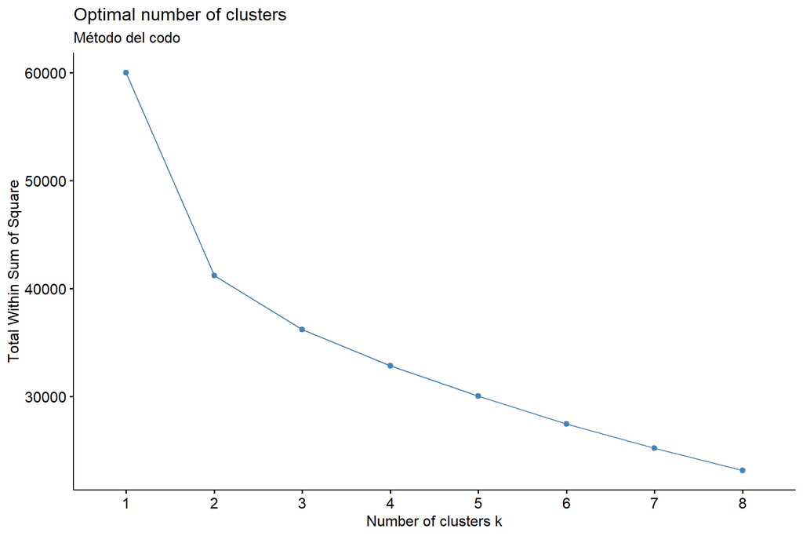

```r
factoextra::fviz_nbclust(
  cluster_sample_scaled,
  kmeans,
  method = "wss",
  k.max = 8,
  nstart = 25
) +
  labs(subtitle = "Método del codo")
```

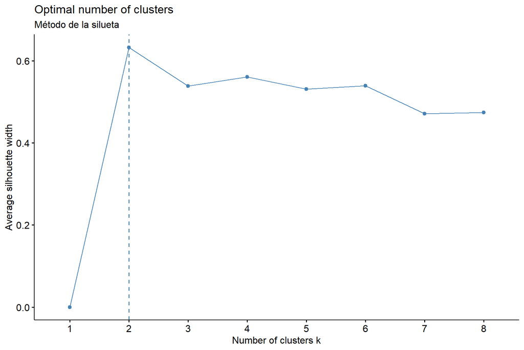

```r
factoextra::fviz_nbclust(
  cluster_sample_scaled,
  kmeans,
  method = "silhouette",
  k.max = 8,
  nstart = 25
) +
  labs(subtitle = "Método de la silueta")
```

El método del codo, la silueta y la interpretabilidad se consideran de forma conjunta. Se mantiene `k = 3`, ya que permite separar perfiles de deuda baja, intermedia y elevada sin introducir una fragmentación difícil de explicar.

## 8.2 K-means con datos originales y normalizados

```r
set.seed(123)
km_original <- kmeans(
  cluster_sample,
  centers = 3,
  nstart = 25
)

set.seed(123)
km_scaled <- kmeans(
  cluster_sample_scaled,
  centers = 3,
  nstart = 25
)

knitr::kable(
  round(km_original$centers, 2),
  caption = "Centroides con datos originales"
)
```

Centroides con datos originales

| DEUDA_Septiembre | DEUDA_Agosto | DEUDA_Julio | DEUDA_Junio | DEUDA_Mayo | DEUDA_Abril | PAGADO_Septiembre | PAGADO_Agosto | PAGADO_Julio | PAGADO_Junio | PAGADO_Mayo | PAGADO_Abril |
| --- | --- | --- | --- | --- | --- | --- | --- | --- | --- | --- | --- |
| 21187.23 | 19330.61 | 17728.74 | 16013.49 | 14895.43 | 14499.29 | 3777.37 | 3829.39 | 3579.32 | 3457.36 | 3503.80 | 4000.54 |
| 289520.85 | 289345.33 | 281781.45 | 266728.76 | 249817.63 | 243873.13 | 18722.82 | 23797.81 | 14889.59 | 16355.51 | 19015.95 | 15388.13 |
| 119112.27 | 116920.19 | 113395.97 | 104427.15 | 97111.21 | 92380.07 | 10057.93 | 9545.08 | 8444.66 | 7431.04 | 6632.04 | 8013.32 |

```r
knitr::kable(
  round(km_scaled$centers, 2),
  caption = "Centroides con datos estandarizados"
)
```

Centroides con datos estandarizados

| DEUDA_Septiembre | DEUDA_Agosto | DEUDA_Julio | DEUDA_Junio | DEUDA_Mayo | DEUDA_Abril | PAGADO_Septiembre | PAGADO_Agosto | PAGADO_Julio | PAGADO_Junio | PAGADO_Mayo | PAGADO_Abril |
| --- | --- | --- | --- | --- | --- | --- | --- | --- | --- | --- | --- |
| -0.39 | -0.40 | -0.41 | -0.41 | -0.40 | -0.39 | -0.14 | -0.10 | -0.12 | -0.11 | -0.12 | -0.10 |
| 3.36 | 3.48 | 3.55 | 3.61 | 3.56 | 3.49 | 1.01 | 0.87 | 0.79 | 0.84 | 1.10 | 0.61 |
| 0.95 | 0.97 | 1.00 | 0.97 | 0.95 | 0.93 | 0.37 | 0.23 | 0.32 | 0.28 | 0.26 | 0.27 |

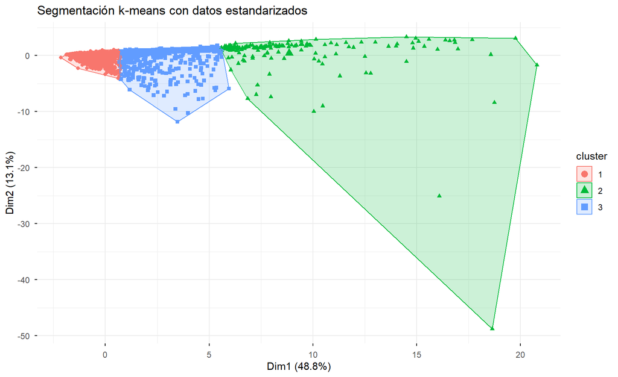

```r
factoextra::fviz_cluster(
  km_scaled,
  data = cluster_sample_scaled,
  geom = "point",
  ellipse.type = "convex",
  ggtheme = theme_minimal(),
  main = "Segmentación k-means con datos estandarizados"
)
```

La versión sin normalizar queda dominada por los importes de mayor magnitud. La versión estandarizada ofrece perfiles más equilibrados y será la referencia para las comparaciones posteriores.

## 8.3 K-medians y PAM

K-medians utiliza la mediana como centro y distancia Manhattan. No debe confundirse con PAM, que utiliza observaciones reales como medoides. Para comparar correctamente ambos enfoques se implementan por separado.

```r
kmedians <- function(x, centers, nstart = 5, iter.max = 100, tol = 1e-6) {
  x <- as.matrix(x)
  best_model <- NULL

  for (start in seq_len(nstart)) {
    center_matrix <- x[sample(seq_len(nrow(x)), centers), , drop = FALSE]

    for (iteration in seq_len(iter.max)) {
      distances <- sapply(
        seq_len(centers),
        function(j) rowSums(abs(sweep(x, 2, center_matrix[j, ], "-")))
      )

      cluster <- max.col(-distances, ties.method = "random")

      new_centers <- do.call(
        rbind,
        lapply(seq_len(centers), function(j) {
          if (sum(cluster == j) == 0) {
            x[sample(seq_len(nrow(x)), 1), ]
          } else {
            apply(x[cluster == j, , drop = FALSE], 2, median)
          }
        })
      )

      if (max(abs(new_centers - center_matrix)) < tol) {
        center_matrix <- new_centers
        break
      }

      center_matrix <- new_centers
    }

    objective <- sum(abs(x - center_matrix[cluster, , drop = FALSE]))

    if (is.null(best_model) || objective < best_model$objective) {
      best_model <- list(
        cluster = cluster,
        centers = center_matrix,
        objective = objective,
        iterations = iteration
      )
    }
  }

  best_model
}
```

```r
set.seed(123)
kmed_model <- kmedians(
  cluster_sample_scaled,
  centers = 3,
  nstart = 5
)

set.seed(123)
pam_model <- cluster::pam(
  cluster_sample_scaled,
  k = 3,
  metric = "manhattan"
)

table(kmedians = kmed_model$cluster)
```

```
## kmedians
##    1    2    3
##  704 2835 1461
```

```r
table(PAM = pam_model$clustering)
```

```
## PAM
##    1    2    3
## 2697 1561  742
```

```r
knitr::kable(
  round(kmed_model$centers, 2),
  caption = "Centros obtenidos con k-medians"
)
```

Centros obtenidos con k-medians

| DEUDA_Septiembre | DEUDA_Agosto | DEUDA_Julio | DEUDA_Junio | DEUDA_Mayo | DEUDA_Abril | PAGADO_Septiembre | PAGADO_Agosto | PAGADO_Julio | PAGADO_Junio | PAGADO_Mayo | PAGADO_Abril |
| --- | --- | --- | --- | --- | --- | --- | --- | --- | --- | --- | --- |
| 1.50 | 1.50 | 1.56 | 1.58 | 1.59 | 1.55 | 0.09 | 0.06 | 0.07 | 0.04 | 0.05 | -0.01 |
| -0.62 | -0.62 | -0.62 | -0.61 | -0.60 | -0.60 | -0.27 | -0.19 | -0.26 | -0.27 | -0.27 | -0.26 |
| 0.01 | 0.04 | 0.05 | 0.07 | 0.03 | 0.01 | -0.16 | -0.13 | -0.19 | -0.18 | -0.18 | -0.18 |

```r
adjusted_rand_index <- function(x, y) {
  tab <- table(x, y)
  choose_two <- function(z) z * (z - 1) / 2
  n <- sum(tab)
  observed <- sum(choose_two(tab))
  rows <- sum(choose_two(rowSums(tab)))
  cols <- sum(choose_two(colSums(tab)))
  total <- choose_two(n)
  expected <- rows * cols / total
  maximum <- (rows + cols) / 2
  (observed - expected) / (maximum - expected)
}

set.seed(123)
sil_idx <- sample(
  seq_len(nrow(cluster_sample_scaled)),
  min(1500, nrow(cluster_sample_scaled))
)

dist_sil <- dist(cluster_sample_scaled[sil_idx, ])

calidad_cluster <- data.frame(
  modelo = c("K-means", "K-medians", "PAM"),
  silueta_media = c(
    mean(cluster::silhouette(km_scaled$cluster[sil_idx], dist_sil)[, 3]),
    mean(cluster::silhouette(kmed_model$cluster[sil_idx], dist_sil)[, 3]),
    mean(cluster::silhouette(pam_model$clustering[sil_idx], dist_sil)[, 3])
  ),
  concordancia_con_kmeans = c(
    1,
    adjusted_rand_index(km_scaled$cluster, kmed_model$cluster),
    adjusted_rand_index(km_scaled$cluster, pam_model$clustering)
  )
)

knitr::kable(
  transform(
    calidad_cluster,
    silueta_media = round(silueta_media, 3),
    concordancia_con_kmeans = round(concordancia_con_kmeans, 3)
  )
)
```

| modelo | silueta_media | concordancia_con_kmeans |
| --- | --- | --- |
| K-means | 0.555 | 1.000 |
| K-medians | 0.308 | 0.424 |
| PAM | 0.288 | 0.393 |

K-medians y PAM reducen la influencia de importes extremos. La tabla permite comparar la cohesión interna y la concordancia con la solución de k-means sin depender del número asignado a cada clúster.

## 8.4 Agrupación con distancia Manhattan

```r
set.seed(123)
km_manhattan <- amap::Kmeans(
  cluster_sample_scaled,
  centers = 3,
  method = "manhattan",
  iter.max = 100
)

table(
  Kmeans_Euclidea = km_scaled$cluster,
  Kmeans_Manhattan = km_manhattan$cluster
)
```

```
##                Kmeans_Manhattan
## Kmeans_Euclidea    1    2    3
##               1    0 3852    0
##               2   49    1  126
##               3    0  475  497
```

```r
adjusted_rand_index(km_scaled$cluster, km_manhattan$cluster)
```

```
## [1] 0.601798
```

La distancia Manhattan es menos sensible a diferencias extremas en una sola variable. La comparación permite comprobar si los perfiles se mantienen al cambiar la geometría utilizada por el algoritmo.

## 8.5 DBSCAN y OPTICS

Los métodos basados en densidad se prueban con distintos valores de `eps`. Para reducir el coste de la matriz de distancias se utiliza una muestra de 3.000 observaciones.

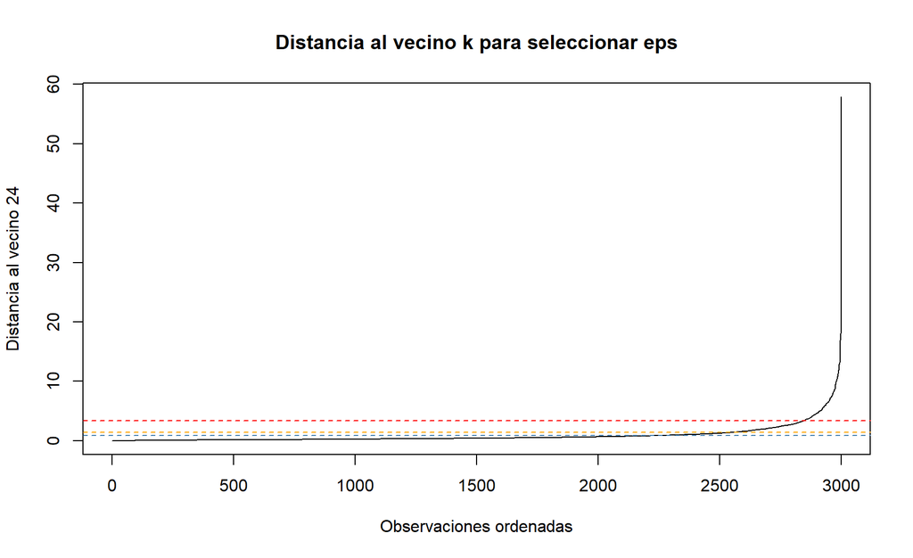

```r
set.seed(123)
idx_density <- sample(
  seq_len(nrow(cluster_sample_scaled)),
  min(3000, nrow(cluster_sample_scaled))
)

density_sample <- cluster_sample_scaled[idx_density, ]
min_pts <- 2 * ncol(density_sample)
kdist <- dbscan::kNNdist(density_sample, k = min_pts)
eps_candidates <- as.numeric(quantile(kdist, c(0.75, 0.85, 0.95)))

plot(
  sort(kdist),
  type = "l",
  main = "Distancia al vecino k para seleccionar eps",
  xlab = "Observaciones ordenadas",
  ylab = paste0("Distancia al vecino ", min_pts)
)
abline(h = eps_candidates, col = c("steelblue", "orange", "red"), lty = 2)
```

```r
dbscan_models <- lapply(
  eps_candidates,
  function(eps_value) {
    dbscan::dbscan(
      density_sample,
      eps = eps_value,
      minPts = min_pts
    )
  }
)

dbscan_summary <- data.frame(
  eps = round(eps_candidates, 3),
  clusters = vapply(
    dbscan_models,
    function(model) length(setdiff(unique(model$cluster), 0)),
    numeric(1)
  ),
  porcentaje_ruido = round(
    100 * vapply(
      dbscan_models,
      function(model) mean(model$cluster == 0),
      numeric(1)
    ),
    2
  )
)

knitr::kable(dbscan_summary)
```

| eps | clusters | porcentaje_ruido |
| --- | --- | --- |
| 0.857 | 1 | 17.97 |
| 1.385 | 1 | 10.73 |
| 3.393 | 1 | 2.90 |

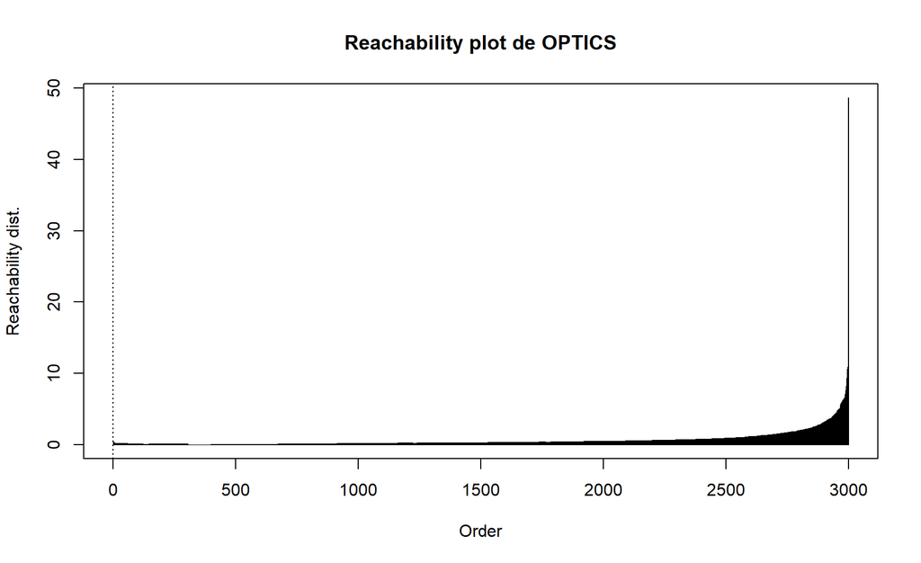

```r
optics_model <- dbscan::optics(
  density_sample,
  minPts = min_pts
)

plot(optics_model, main = "Reachability plot de OPTICS")
```

```r
optics_clusters <- dbscan::extractDBSCAN(
  optics_model,
  eps_cl = eps_candidates[2]
)

table(optics_clusters$cluster)
```

```
##
##    0    1
##  322 2678
```

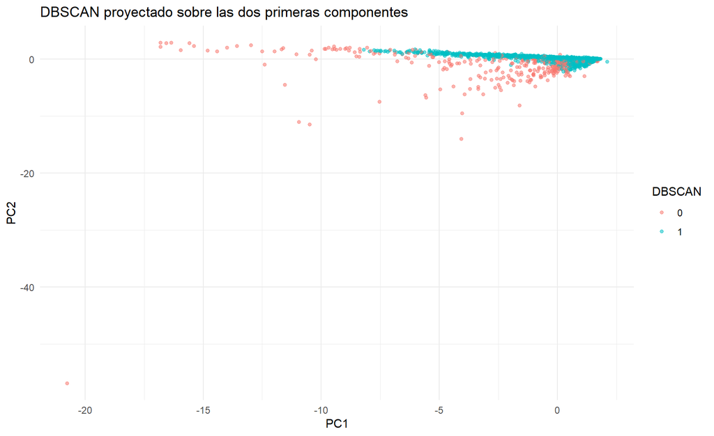

```r
pca_density <- prcomp(density_sample)$x[, 1:2] |>
  as.data.frame()

pca_density$DBSCAN <- factor(dbscan_models[[2]]$cluster)
pca_density$OPTICS <- factor(optics_clusters$cluster)

ggplot(pca_density, aes(x = PC1, y = PC2, color = DBSCAN)) +
  geom_point(alpha = 0.55, size = 1.2) +
  labs(title = "DBSCAN proyectado sobre las dos primeras componentes") +
  theme_minimal()
```

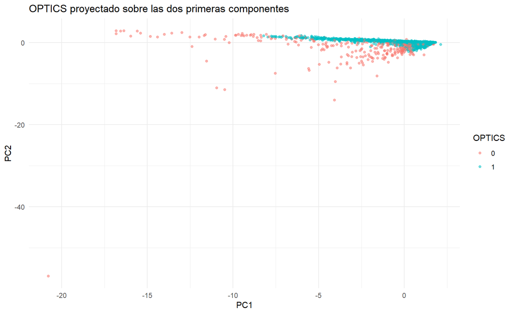

```r
ggplot(pca_density, aes(x = PC1, y = PC2, color = OPTICS)) +
  geom_point(alpha = 0.55, size = 1.2) +
  labs(title = "OPTICS proyectado sobre las dos primeras componentes") +
  theme_minimal()
```

Si la mayor parte de las observaciones se concentra en un único grupo o se clasifica como ruido, la estructura del dataset no está bien representada por regiones de densidad separadas. En ese caso k-means, k-medians o PAM ofrecen una segmentación más estable e interpretable.

# 9 Modelos supervisados

## 9.1 Preparación de entrenamiento y test

Se utiliza una división estratificada del 70% para entrenamiento y 30% para test. El muestreo estratificado mantiene la proporción de impagos en ambos conjuntos.

```r
datos_modelo <- clientes |>
  dplyr::select(-ID, -GEdad)

set.seed(123)
train_index <- caret::createDataPartition(
  datos_modelo$Pago,
  p = 0.70,
  list = FALSE
)

train_data <- datos_modelo[train_index, ]
test_data <- datos_modelo[-train_index, ]

data.frame(
  conjunto = c("Entrenamiento", "Test"),
  observaciones = c(nrow(train_data), nrow(test_data)),
  porcentaje_impago = round(
    100 * c(
      mean(train_data$Pago == "Impago"),
      mean(test_data$Pago == "Impago")
    ),
    2
  )
)
```

```
##        conjunto observaciones porcentaje_impago
## 1 Entrenamiento         20722             22.31
## 2          Test          8879             22.31
```

## 9.2 Árbol de decisión sin poda y podado

```r
set.seed(123)
arbol_completo <- rpart::rpart(
  Pago ~ .,
  data = train_data,
  method = "class",
  control = rpart::rpart.control(
    cp = 0,
    minsplit = 50,
    maxdepth = 12,
    xval = 10
  )
)

cp_optimo <- arbol_completo$cptable[
  which.min(arbol_completo$cptable[, "xerror"]),
  "CP"
]

arbol_podado <- prune(
  arbol_completo,
  cp = cp_optimo
)

cp_optimo
```

```
## [1] 0.002595156
```

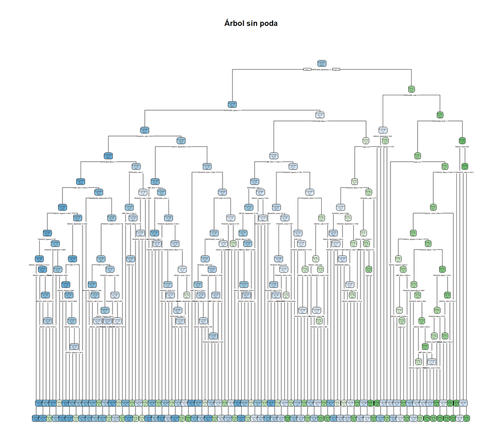

```r
rpart.plot::rpart.plot(
  arbol_completo,
  type = 2,
  extra = 104,
  fallen.leaves = TRUE,
  main = "Árbol sin poda"
)
```

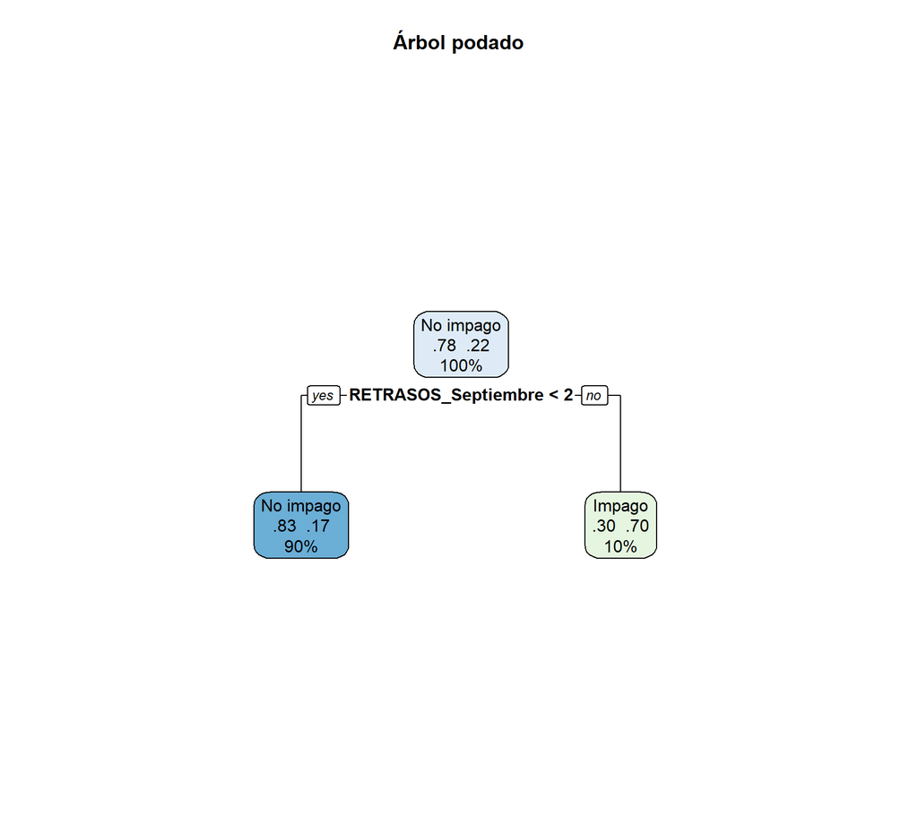

```r
rpart.plot::rpart.plot(
  arbol_podado,
  type = 2,
  extra = 104,
  fallen.leaves = TRUE,
  main = "Árbol podado"
)
```

```r
pred_arbol_completo <- predict(
  arbol_completo,
  test_data,
  type = "class"
)

pred_arbol_podado <- predict(
  arbol_podado,
  test_data,
  type = "class"
)

cm_arbol_completo <- caret::confusionMatrix(
  pred_arbol_completo,
  test_data$Pago,
  positive = "Impago"
)

cm_arbol_podado <- caret::confusionMatrix(
  pred_arbol_podado,
  test_data$Pago,
  positive = "Impago"
)

cm_arbol_completo
```

```
## Confusion Matrix and Statistics
##
##            Reference
## Prediction  No impago Impago
##   No impago      6388   1256
##   Impago          510    725
##
##                Accuracy : 0.8011
##                  95% CI : (0.7926, 0.8094)
##     No Information Rate : 0.7769
##     P-Value [Acc > NIR] : 0.00000001515
##
##                   Kappa : 0.3373
##
##  Mcnemar's Test P-Value : < 0.00000000000000022
##
##             Sensitivity : 0.36598
##             Specificity : 0.92607
##          Pos Pred Value : 0.58704
##          Neg Pred Value : 0.83569
##              Prevalence : 0.22311
##          Detection Rate : 0.08165
##    Detection Prevalence : 0.13909
##       Balanced Accuracy : 0.64602
##
##        'Positive' Class : Impago
##
```

```r
cm_arbol_podado
```

```
## Confusion Matrix and Statistics
##
##            Reference
## Prediction  No impago Impago
##   No impago      6620   1306
##   Impago          278    675
##
##                Accuracy : 0.8216
##                  95% CI : (0.8135, 0.8295)
##     No Information Rate : 0.7769
##     P-Value [Acc > NIR] : < 0.00000000000000022
##
##                   Kappa : 0.3686
##
##  Mcnemar's Test P-Value : < 0.00000000000000022
##
##             Sensitivity : 0.34074
##             Specificity : 0.95970
##          Pos Pred Value : 0.70829
##          Neg Pred Value : 0.83523
##              Prevalence : 0.22311
##          Detection Rate : 0.07602
##    Detection Prevalence : 0.10733
##       Balanced Accuracy : 0.65022
##
##        'Positive' Class : Impago
##
```

La poda reduce la complejidad y facilita la interpretación. La comparación no debe basarse únicamente en accuracy: sensibilidad, especificidad, balanced accuracy y Kappa permiten comprobar si el modelo identifica la clase de impago.

## 9.3 Random Forest con muestreo balanceado

Random Forest permite capturar relaciones no lineales y combinaciones entre variables. Para evitar que cada árbol se concentre en la clase mayoritaria, se equilibra el bootstrap interno mediante `sampsize`.

```r
class_counts <- table(train_data$Pago)
balanced_size <- min(class_counts)

set.seed(123)
rf_balanced <- randomForest::randomForest(
  Pago ~ .,
  data = train_data,
  ntree = 300,
  mtry = floor(sqrt(ncol(train_data) - 1)),
  importance = TRUE,
  sampsize = rep(balanced_size, length(class_counts))
)

rf_balanced
```

```
##
## Call:
##  randomForest(formula = Pago ~ ., data = train_data, ntree = 300,      mtry = floor(sqrt(ncol(train_data) - 1)), importance = TRUE,      sampsize = rep(balanced_size, length(class_counts)))
##                Type of random forest: classification
##                      Number of trees: 300
## No. of variables tried at each split: 4
##
##         OOB estimate of  error rate: 21.75%
## Confusion matrix:
##           No impago Impago class.error
## No impago     13557   2541   0.1578457
## Impago         1966   2658   0.4251730
```

```r
pred_rf <- predict(
  rf_balanced,
  test_data,
  type = "class"
)

cm_rf <- caret::confusionMatrix(
  pred_rf,
  test_data$Pago,
  positive = "Impago"
)

cm_rf
```

```
## Confusion Matrix and Statistics
##
##            Reference
## Prediction  No impago Impago
##   No impago      5793    822
##   Impago         1105   1159
##
##                Accuracy : 0.783
##                  95% CI : (0.7742, 0.7915)
##     No Information Rate : 0.7769
##     P-Value [Acc > NIR] : 0.086
##
##                   Kappa : 0.4043
##
##  Mcnemar's Test P-Value : 0.0000000001327
##
##             Sensitivity : 0.5851
##             Specificity : 0.8398
##          Pos Pred Value : 0.5119
##          Neg Pred Value : 0.8757
##              Prevalence : 0.2231
##          Detection Rate : 0.1305
##    Detection Prevalence : 0.2550
##       Balanced Accuracy : 0.7124
##
##        'Positive' Class : Impago
##
```

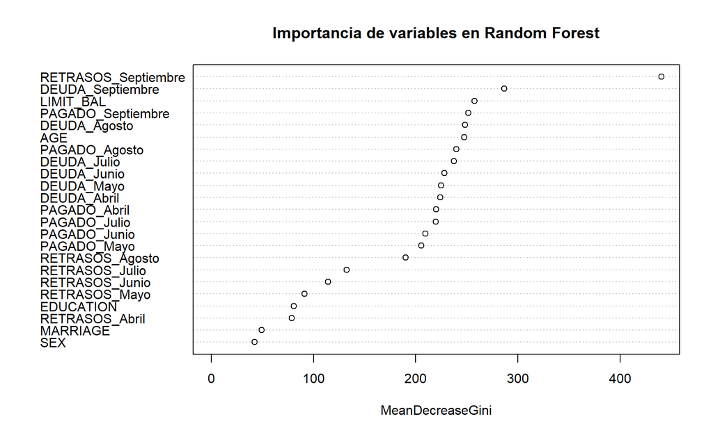

```r
randomForest::varImpPlot(
  rf_balanced,
  type = 2,
  main = "Importancia de variables en Random Forest"
)
```